# GridMaking

wkumler

July 23, 2019

## Intro things

After looking at a lot of mass-spec data, I began to notice that the m/z values that the instrument collects have rather a lot of interesting patterns to them. One of these is the instrument’s method of collecting data in m/z “swaths” - rather that producing the most accurate possible mass, it looks like the instrument measures m/z at relatively few points, which are mostly preserved across retention time scans. This can be seen below in two peaks pulled from Natalie’s ODZ standard runs, per Laura’s recommendation.

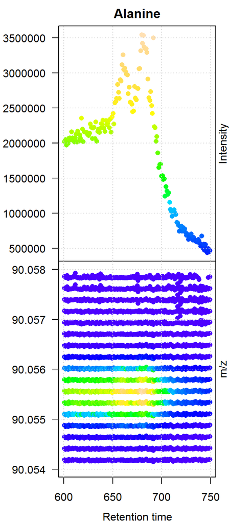

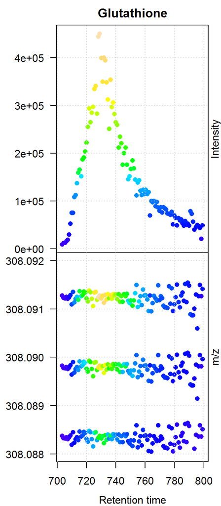

```r
# pos_path <- "Z:/1_QEdata/Will/PeakPickingData/positive/"
# if(!dir.exists(pos_path)){stop("Map yo Z: drive!")}
# pos_files <- list.files(pos_path, full.names = T)
pos_file <- "190626_Std_4uMStdsMix1InH2O_1.mzML"

will_plotXIC <- function (x, main = "", col = "grey", colramp = topo.colors,
                                grid.color = "lightgrey", pch = 21, yl = NULL,
                                layout = matrix(1:2, ncol = 1), mn = NULL, ...) {
  x <- suppressWarnings(as(x, "data.frame"))
  if (is.matrix(layout))
    layout(layout)
  bpi <- unlist(lapply(split(x$i, x$rt), max, na.rm = TRUE))
  brks <- lattice::do.breaks(range(x$i), nint = 256)
  par(mar = c(0, 4.5, 2, 1))
  plot(as.numeric(names(bpi)), bpi, xaxt = "n", col = col,
       main = mn, bg = lattice:::level.colors(bpi, at = brks, col.regions = colramp),
       xlab = "", pch = pch, ylab = "", las = 2,
       ...)
  mtext(side = 4, line = 0, "Intensity", cex = par("cex.lab"))
  grid(col = grid.color)
  par(mar = c(3.5, 4.5, 0, 1))
  plot(x$rt, x$mz, main = "", pch = pch, col = col, xlab = "",
       ylab = "", yaxt = "n", ylim = yl,
       bg = lattice:::level.colors(x$i, at = brks, col.regions = colramp), ...)
  axis(side = 2, las = 2)
  grid(col = grid.color)
  mtext(side = 1, line = 2.5, "Retention time", cex = par("cex.lab"))
  mtext(side = 4, line = 0, "m/z", cex = par("cex.lab"))
}


raw_data_2 <- readMSData(files = pos_file, mode = "onDisk",
                         centroided. = F, msLevel. = 1)

raw_data_2 %>%
  filterRt(c(600, 750)) %>%
  filterMz(c(90.054, 90.058)) %>%
  will_plotXIC(col=NA, yl=c(90.054, 90.058), mn="Alanine")

raw_data_2 %>%
  filterRt(c(650, 800)) %>%
  filterMz(c(308.088, 308.092)) %>%
  will_plotXIC(col=NA, yl=c(308.088, 308.092), mn="Glutathione")
```

However, the 2.5 ppm number is pretty much magic. It’s what I was told that Orbitraps produce, and seems to be the general online consensus. The most relevant paper I’ve found on the topic is [here](https://doi.org/10.1074/mcp.T500030-MCP200), titled “Parts per Million Mass Accuracy on an Orbitrap Mass Spectrometer via Lock Mass Injection into a C-trap”. It uses measured deviation from lock masses to calculate a ppm error, and report maximal deviations of less than 2ppm. The Thermo website, on the other hand, claims [sub-1ppm accuracy for the QE](https://www.thermofisher.com/order/catalog/product/IQLAAEGAAPFALGMAZR) and [reports a resolution of up to 240,000 (FWHM) at 200 Da for the QE HF](https://www.thermofisher.com/order/catalog/product/IQLAAEGAAPFALGMBFZ).

Consider also that our QE HF can measure at a range of resolutions, and it’s understandable that the “error”, whatever it means, isn’t matching exactly with our measurements. This particular file was run at a resolution of 60,000, according to Xcalibur -> Right Click -> View -> Report -> Instrument Method. This doesn’t help all that much, though, because I have no idea how to go from resolution to ppm.

[IUPAC](http://goldbook.iupac.org/terms/view/R05318) provides a peak width definition of:

> For a single peak made up of singly charged ions at mass m in a mass spectrum, the resolution may be expressed as $\frac{m}{\Delta m}$ where $\Delta$m is the width of the peak at a height which is a specified fraction of the maximum peak height. It is recommended that one of three values 50%, 5% or 0.5% should always be used. For an isolated symmetrical peak recorded with a system which is linear in the range between 5% and 10% levels of the peak, the 5% peak width definition is technically equivalent to the 10% valley definition. A common standard is the definition of resolution based upon $\Delta$m being Full Width of the peak at Half its Maximum height, sometimes abbreviated ‘FWHM’. This acronym should preferably be defined the first time it is used.

The funny thing here is “width of the peak”. Are we measuring that in Da? I’ve graphed some nicely-shaped peaks below to obtain their FWHM. The peaks here are a histogram of m/z values

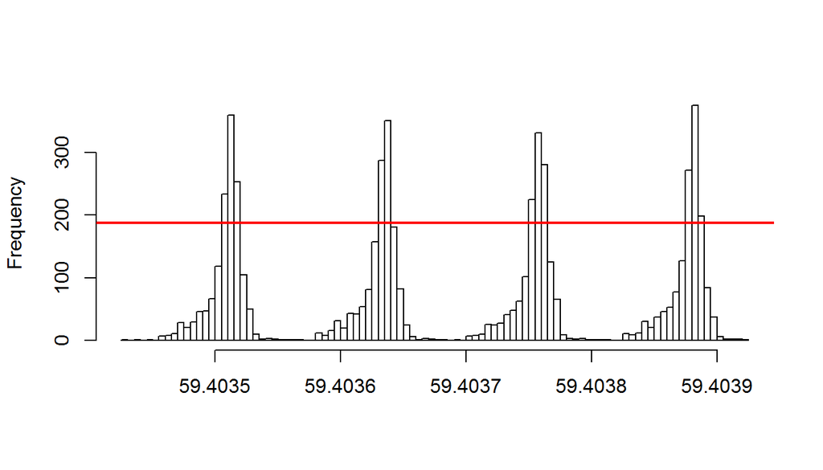

```r
library(ggplot2)

some_peaks <- raw_data_2 %>%
  filterMz(c(59.4, 59.404)) %>%
  mz() %>%
  unlist() %>%
  unname()
peak_hist <- hist(some_peaks, breaks = 100, main = "", xlab = "")
abline(h=max(peak_hist$counts)/2, col="red", lwd=2)
```

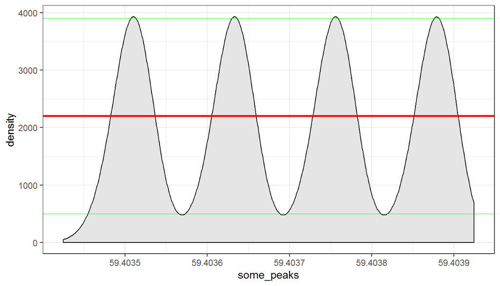

```r
ggplot() + geom_density(aes(x=some_peaks), fill="grey90") +
  geom_hline(aes(yintercept=(3900-500)/2+500), color="red", size=1) +
  geom_hline(aes(yintercept=500), color="green", size=0.2) +
  geom_hline(aes(yintercept=3900), color="green", size=0.2) +
  theme_bw()
```

The ggplot is easier to measure FWHM on, so I’ve added a line at my best guess for its FWHM. The width here looks like 0.00005 Da (one grid square width, at two grid squares per 0.0001 Da). For the more precise histograms, the FWHM looks more like it’s 0.000015 Da (20 bins per Da, FWHM $\approx$ 3 bins).

Naively applying the above formula with our the peak widths we have above returns $\frac{59.4035}{0.00005} = 1188070$. I suspect that’s meant to be close to the planned FWHM of 60,000, but is way higher than predicted.

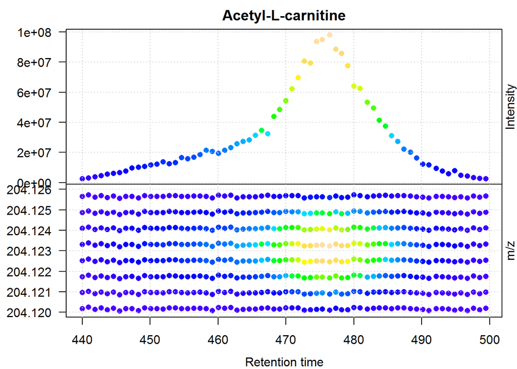

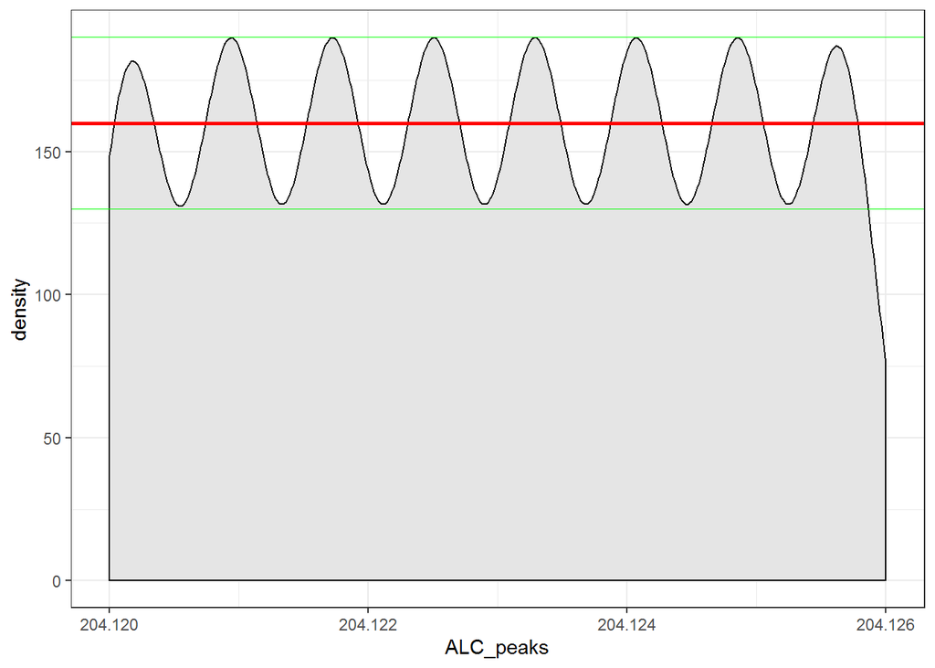

```r
ALC_rt <- c(c(440, 500))
ALC_mz <- c(204.120, 204.126)

raw_data_2 %>%
  filterRt(ALC_rt) %>%
  filterMz(ALC_mz) %>%
  will_plotXIC(col=NA, yl=ALC_mz, mn="Acetyl-L-carnitine")

ALC_peaks <- raw_data_2 %>%
  filterMz(ALC_mz) %>%
  mz() %>%
  unlist() %>%
  unname()

peak_counts <- hist(ALC_peaks, breaks = 100, main = "", xlab = "")$counts
abline(h=max(peak_counts)/2, col="red", lwd=2)

ggplot() + geom_density(aes(x=ALC_peaks), fill="grey90") +
  geom_hline(aes(yintercept=(190-130)/2+130), color="red", size=1) +
  geom_hline(aes(yintercept=130), color="green", size=0.2) +
  geom_hline(aes(yintercept=190), color="green", size=0.2) +
  theme_bw()
```

## Gridding

So that all seems… useless. Sure, it’s interesting, but given that we’re working exclusively with centroided data it’s hard to imagine it actually making a difference.

There are a few reasons I’m interested in these patterns. From most likely to least likely (and, ironically, from least interesting to most):

- Reduced file sizes
  - Quantizing m/z values allows significantly greater compression. I’d guess file size reductions of maybe 30%?
- Faster processing
  - Same as above. Rather than handling each m/z value as new and surprising, algorithms can handle square data much more readily than ragged data
- More powerful blank subtraction
  - Here’s where it gets interesting. Once the files are in a grid format, we can datum-by-datum subtract blanks. Given how noisy even our blanks are, I’m hoping this significantly reduces the false positives in the data
  - For things like plastics that may actually exist in our blanks, this would actually let us study those compounds because it’d identify the differences between the blanks and the samples, rather than throwing out any peak found in the blank
- Cleaner peaks
  - I’m optimistic about this one. Given both xcms and MSDIAL currently pick a huge amount of noise, a combination of the m/z quantizing and the gridded nature should provide a clearer signal
  - Additionally, it’s possible that I’ll be able to reduce m/z noise because the m/z scatter appears to be cumulative over the course of a swath (each m/z swath inherits the scatter from the previous swath and adds its own noise). As this process gets up into the higher masses, it’s concievable that the m/z crossover noise would become a problem for the peakfinding algorithms. I don’t actually think this is the case because the distance between swaths also increases with mass, but cumulative noise is a scary thing.

There are two main problems that come up when trying to process the MS data into a grid. First, we can’t simply slice by ordinal (first, second, etc.) m/z swath because there are a lot of empty values. I started out by trying to grab the first m/z value from each rt scan, only to realize that the data was ragged - I ran out of m/z values much sooner in some scans than in others.

The solution to that problem is to identify the m/z swaths and slice in between them. In the images above, one can easily see the m/z swaths and mentally bin them into groups, so we’ll get the computer to do that for us.

This idea introduces a new challenge - the bins aren’t all the same distance apart: instead, they’re proportional to mass. In theory, they would increase as some function of the instrumental accuracy, but the above discussion shows that it’s not as simple as grabbing a bin every 0.0001+0.0000025*mass.

There are *layers* to this binning process. The most obvious one is the tendency to group near round m/z numbers, especially at low mass values. This is simply because molecules come in round numbers of AMU.

Within that large-scale peak, there’s often smaller-scale variability that appears to be fairly unique between Da. I suspect this is due to the mass defect, with one potential peak for a nitrogen containing compound, another for one that has a bunch of oxygen, another for a lipid, etc.

At the lowest level, we have the individual scans across a peak. This is what’s generated by the mass spectrometer’s binning as it reports values.

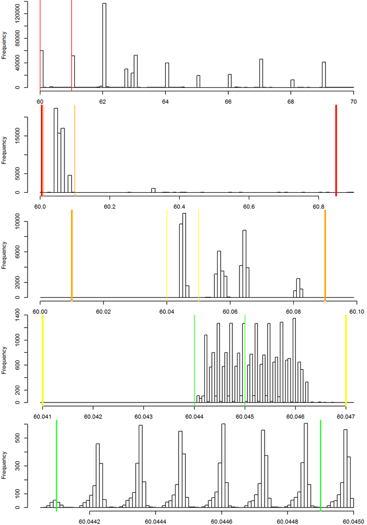

```r
# It's apparently faster to load the entire m/z data set once than to filter repeatedly
mz_raw <- raw_data_2 %>%
  mz() %>%
  unname() %>%
  unlist()

par(mfrow=c(5,1))
par(mar=c(2,4,0,0.1))

a <- mz_raw[mz_raw>60&mz_raw<70]
hist(a, breaks = 100, main="")
abline(v=c(60, 61), col="red")

a <- mz_raw[mz_raw>60&mz_raw<60.9]
hist(a, breaks = 100, main="")
abline(v=c(60.005, 60.85), col="red", lwd=3)
abline(v=c(60.01, 60.1), col="orange")

a <- mz_raw[mz_raw>60.0&mz_raw<60.1]
hist(a, breaks = 100, main="")
abline(v=c(60.01, 60.09), col="orange", lwd=3)
abline(v=c(60.04, 60.05), col="yellow")

a <- mz_raw[mz_raw>60.04&mz_raw<60.05]
hist(a, breaks = 100, main="")
abline(v=c(60.041, 60.047), col="yellow", lwd=3)
abline(v=c(60.044, 60.045), col="green")

a <- mz_raw[mz_raw>60.044&mz_raw<60.045]
hist(a, breaks = 100, main="")
abline(v=c(60.0441, 60.0449), col="green", lwd=2)
```

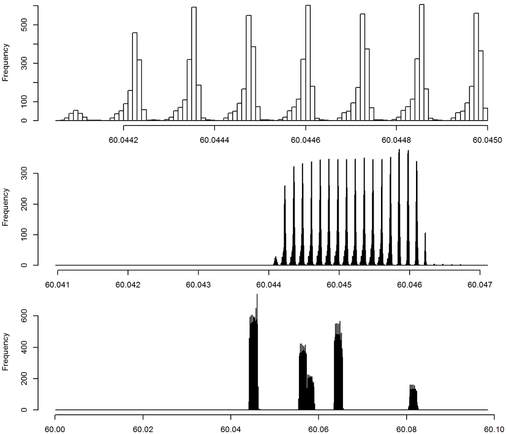

```r
par(mfrow=c(3,1))
par(mar=c(2,4,0,0.1))

a <- mz_raw[mz_raw>60.044&mz_raw<60.045]
b <- hist(a,breaks = 100, main="")
a <- mz_raw[mz_raw>60.04&mz_raw<60.05]
b <- hist(a,breaks = 1000, main="")
a <- mz_raw[mz_raw>60.0&mz_raw<60.1]
b <- hist(a,breaks = 10000, main="")
```

When we ask for the local maxima, there are essentially two parameters to keep track of. The number of bins in the histogram determines the resolution of the peak, and the **span** of the maxima finder determins how many bins to look left and right before determining that it is, indeed a local maximum.

Parameters that work well for low-mass compounds break down when applied to higher masses; either the span or the binwidth will need to be modified as a function of mass to counter this.

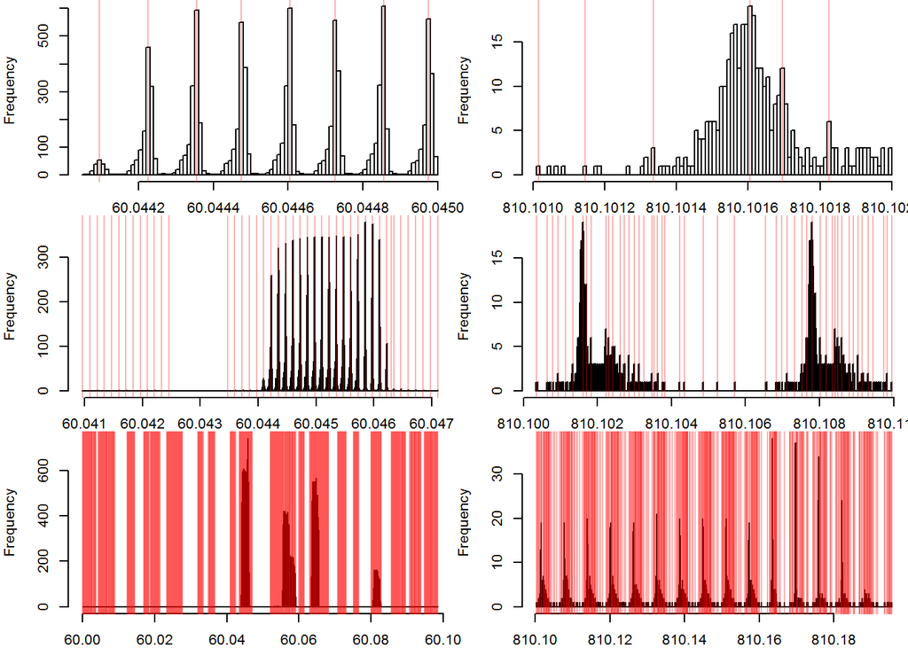

```r
par(mfcol=c(3,2))
par(mar=c(2,4,0,0.1))

a <- mz_raw[mz_raw>60.044&mz_raw<60.045]
b <- hist(a,breaks = 100, main="")
c <- MALDIquant:::.localMaxima(b$counts, 5)
abline(v=b$mids[c], col=rgb(red = 1, green = 0, blue = 0, alpha = 0.3))
a <- mz_raw[mz_raw>60.04&mz_raw<60.05]
b <- hist(a,breaks = 1000, main="")
c <- MALDIquant:::.localMaxima(b$counts, 5)
abline(v=b$mids[c], col=rgb(red = 1, green = 0, blue = 0, alpha = 0.3))
a <- mz_raw[mz_raw>60.0&mz_raw<60.1]
b <- hist(a,breaks = 10000, main="")
c <- MALDIquant:::.localMaxima(b$counts, 5)
abline(v=b$mids[c], col=rgb(red = 1, green = 0, blue = 0, alpha = 0.3))

a <- mz_raw[mz_raw>810.101&mz_raw<810.102]
b <- hist(a,breaks = 100, main="")
c <- MALDIquant:::.localMaxima(b$counts, 5)
abline(v=b$mids[c], col=rgb(red = 1, green = 0, blue = 0, alpha = 0.3))
a <- mz_raw[mz_raw>810.10&mz_raw<810.11]
b <- hist(a,breaks = 1000, main="")
c <- MALDIquant:::.localMaxima(b$counts, 5)
abline(v=b$mids[c], col=rgb(red = 1, green = 0, blue = 0, alpha = 0.3))
a <- mz_raw[mz_raw>810.1&mz_raw<810.2]
b <- hist(a,breaks = 10000, main="")
c <- MALDIquant:::.localMaxima(b$counts, 5)
abline(v=b$mids[c], col=rgb(red = 1, green = 0, blue = 0, alpha = 0.3))
```

In the left column, I’ve tuned the binwidth and span parameters to accurately pick those peaks. On the right, the same parameters applied to an 800 Da compound chooses several false positives, resulting in a more jagged spacing of “maxima”.

I’d hoped that finding the spacing between the different parameters would be as simple as calling diff() on the x-axis values of the chosen peaks, but there’s too much noise in the data to discern any reasonable pattern.

Instead, by tuning the 810 compound as well, we get a line with a slope of 1/6 and an intercept of essentially zero. So for each compound, an appropriate span would be its mass divided by six. For our 60 Da compound, we’ll use a span of 10. For a 200 Da compound, a span of 33, and so on up to our 810 Da compound with a span of 135.

In theory, it would be possible to correlate this value back to the mass accuracy of the instrument, assuming that the distance between said peaks is dependent upon it, allowing an *a priori* prediction of the span, but the above discussion of resolution makes this hard to do.

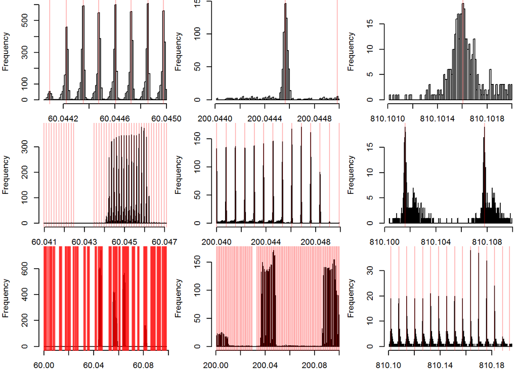

```r
par(mfcol=c(3,3))
par(mar=c(2,4,0,0.1))

span_init <- 1/6
span <- round(span_init*60)
a <- mz_raw[mz_raw>60.044&mz_raw<60.045]
b <- hist(a,breaks = 100, main="")
c <- MALDIquant:::.localMaxima(b$counts, span)
abline(v=b$mids[c], col=rgb(red = 1, green = 0, blue = 0, alpha = 0.3))
a <- mz_raw[mz_raw>60.04&mz_raw<60.05]
b <- hist(a,breaks = 1000, main="")
c <- MALDIquant:::.localMaxima(b$counts, span)
abline(v=b$mids[c], col=rgb(red = 1, green = 0, blue = 0, alpha = 0.3))
a <- mz_raw[mz_raw>60.0&mz_raw<60.1]
b <- hist(a,breaks = 10000, main="")
c <- MALDIquant:::.localMaxima(b$counts, span)
abline(v=b$mids[c], col=rgb(red = 1, green = 0, blue = 0, alpha = 0.3))

span <- round(span_init*200)
a <- mz_raw[mz_raw>200.044&mz_raw<200.045]
b <- hist(a,breaks = 100, main="")
c <- MALDIquant:::.localMaxima(b$counts, span)
abline(v=b$mids[c], col=rgb(red = 1, green = 0, blue = 0, alpha = 0.3))
a <- mz_raw[mz_raw>200.04&mz_raw<200.05]
b <- hist(a,breaks = 1000, main="")
c <- MALDIquant:::.localMaxima(b$counts, span)
abline(v=b$mids[c], col=rgb(red = 1, green = 0, blue = 0, alpha = 0.3))
a <- mz_raw[mz_raw>200.0&mz_raw<200.1]
b <- hist(a,breaks = 10000, main="")
c <- MALDIquant:::.localMaxima(b$counts, span)
abline(v=b$mids[c], col=rgb(red = 1, green = 0, blue = 0, alpha = 0.3))

span <- round(span_init*810)
a <- mz_raw[mz_raw>810.101&mz_raw<810.102]
b <- hist(a,breaks = 100, main="")
c <- MALDIquant:::.localMaxima(b$counts, span)
abline(v=b$mids[c], col=rgb(red = 1, green = 0, blue = 0, alpha = 0.3))
a <- mz_raw[mz_raw>810.10&mz_raw<810.11]
b <- hist(a,breaks = 1000, main="")
c <- MALDIquant:::.localMaxima(b$counts, span)
abline(v=b$mids[c], col=rgb(red = 1, green = 0, blue = 0, alpha = 0.3))
a <- mz_raw[mz_raw>810.1&mz_raw<810.2]
b <- hist(a,breaks = 10000, main="")
c <- MALDIquant:::.localMaxima(b$counts, span)
abline(v=b$mids[c], col=rgb(red = 1, green = 0, blue = 0, alpha = 0.3))
```

## Fitting to grid

Now that we’ve found a reasonable formula for finding local maxima in the histograms, we need to apply it to find the distance between m/z swaths. The general plan here is to cut the whole m/z range into bins of 6 Da (6 because then the span will be the same for all of them), and within each bin, calculate the median distance between swaths (median because mean is highly subject to randomness).

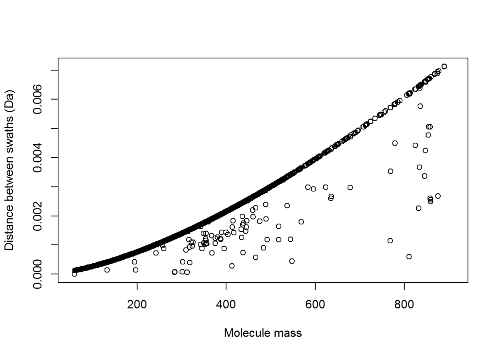

```r
bin_minima <- seq(57, 908.9, 6)
getMeds <- function(bin_min){
  span <- round(bin_min/6)
  raw_i <- mz_raw[mz_raw>(bin_min)&mz_raw<(bin_min+6)]
  bin_meds <- numeric(0)
  peak_mids <- list()
  for(j in seq(0, 5.9, 0.1)){
    raw_bin_j <- raw_i[raw_i>(bin_min+j)&raw_i<(bin_min+j+0.1)]
    if(length(raw_bin_j)!=0){
      hist_bin_j <- hist(raw_bin_j, breaks = 10000, plot = F)
      if(max(hist_bin_j$counts)>3){
        peak_idxs <- MALDIquant:::.localMaxima(hist_bin_j$counts, span)
        peak_masses <- hist_bin_j$mids[peak_idxs]
        swath_deltas <- diff(peak_masses)
        bin_meds[(j+0.1)*10] <- median(swath_deltas)
        peak_mids[[(j+0.1)*10]] <- peak_masses
      } else {
        bin_meds[(j+0.1)*10] <- NA
        peak_mids[[(j+0.1)*10]] <- NA
      }
    } else {
      bin_meds[(j+0.1)*10] <- NA
      peak_mids[[(j+0.1)*10]] <- NA
    }
  }
  return(list(bin_meds, peak_mids))
}


library(parallel)
cl <- makeCluster(detectCores()-1)
clusterExport(cl=cl, varlist=c("mz_raw"))
med_output <- parLapply(cl, bin_minima, getMeds)
stopCluster(cl)

meds <- unlist(lapply(med_output, `[[`, 1))
xvals <- seq(57, 908.9, 0.1)
plot(xvals, meds, ylab="Distance between swaths (Da)", xlab="Molecule mass")
```

Now that we’ve got the distances between swaths over our whole mass range, we’ll want to fit it to a formula so that we can cut it wherever we’d like. We fit it to a second degree polynomial model because the data appears to be slightly curved and a linear fit didn’t work out well.

We actually run the polynomial fit model twice, once to remove all the noise that shows up underneath our nice curve, and a second time to get a highly accurate fitted model.

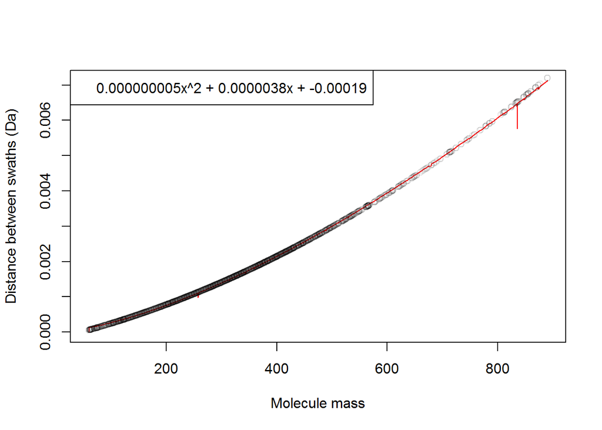

```r
xvals_nafree <- xvals[!is.na(meds)]
meds_nafree <- meds[!is.na(meds)]
na_poly <- lm(meds_nafree~poly(xvals_nafree, 2, raw = T))$coefficients
np_vals <- sapply(xvals_nafree, function(x){na_poly[3]*x**2+na_poly[2]*x+na_poly[1]-0.0001})

goodints <- meds_nafree>np_vals-0.0001
meds_clean <- meds_nafree[goodints]
xvals_clean <- xvals_nafree[goodints]
np_coef <- lm(meds_clean~poly(xvals_clean,2,raw = T))$coefficients
median_eq <- function(x){np_coef[3]*x**2+np_coef[2]*x+np_coef[1]}

options(scipen=999)
plot(xvals_clean, meds_clean, pch=19, cex=0.2, type="l", col="red",
     ylab="Distance between swaths (Da)", xlab="Molecule mass")
points(xvals_clean, median_eq(xvals_clean), col=rgb(0, 0, 0, 0.1))
legend("topleft", legend =
         paste0(round(np_coef[3], 10), expression(x^2), " + ",
                round(np_coef[2], 7), "x + ", round(np_coef[1], 5)))
```

Looks like a pretty darn good fit. So for a given mass, the width of the swath will be calculatable. We can check this by plotting our histograms from above again, but using the formula to identify bin spaces.

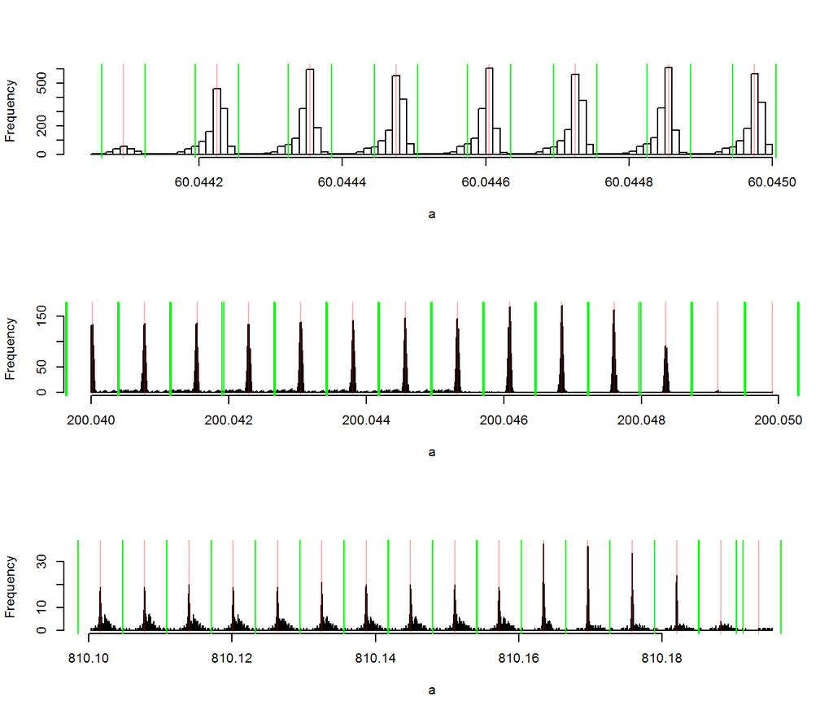

```r
mids <- unlist(lapply(med_output, `[[`, 2))
mids_clean <- mids[!is.na(mids)]
bin_fronts <- mids_clean-median_eq(mids_clean)/2
bin_ends <- mids_clean+median_eq(mids_clean)/2

par(mfrow=c(3,1))
palered <- rgb(red = 1, green = 0, blue = 0, alpha = 0.3)

a <- mz_raw[mz_raw>60.044&mz_raw<60.045]
b <- hist(a,breaks = 100, main="")
abline(v=mids, col=palered)
abline(v=bin_fronts, col="green")
abline(v=bin_ends, col="green")

a <- mz_raw[mz_raw>200.04&mz_raw<200.05]
b <- hist(a,breaks = 1000, main="")
abline(v=mids, col=palered)
abline(v=bin_fronts, col="green")
abline(v=bin_ends, col="green")

a <- mz_raw[mz_raw>810.1&mz_raw<810.2]
b <- hist(a,breaks = 10000, main="")
abline(v=mids, col=palered)
abline(v=bin_fronts, col="green")
abline(v=bin_ends, col="green")
```

However, it’s not a *perfect* fit. This is clear in the first graph at 60 Da where the bins don’t overlap completely and leave gaps between them. This is also one of the places where the model fits least well, as in the gap between the red data points and the predicted open circles.

So, it’s time to do what I should have done a long time ago and simply use the halfway point between the peaks to identify bins. This way, each data point is guaranteed to fall within a bin and we don’t have to worry about a best-fit model because we’re instead using the real data.

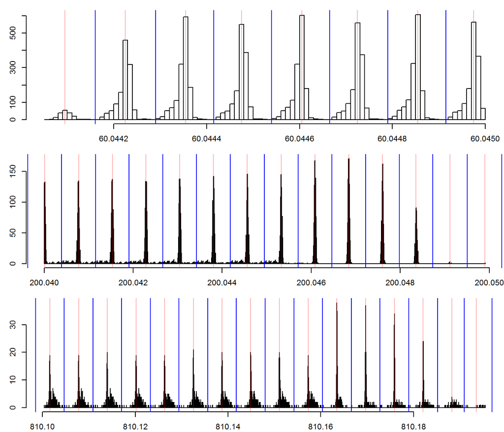

```r
bin_minima <- seq(57, 908.9, 6)
getMeds <- function(bin_min){
  span <- round(bin_min/6)
  raw_i <- mz_raw[mz_raw>(bin_min)&mz_raw<(bin_min+6)]
  peak_mids <- list()
  for(j in seq(0, 5.9, 0.1)){
    raw_bin_j <- raw_i[raw_i>(bin_min+j)&raw_i<(bin_min+j+0.1)]
    if(length(raw_bin_j)!=0){
      hist_bin_j <- hist(raw_bin_j, breaks = 10000, plot = F)
      peak_idxs <- MALDIquant:::.localMaxima(hist_bin_j$counts, span)
      peak_mids[[(j+0.1)*10]] <- hist_bin_j$mids[peak_idxs]
    }
  }
  return(peak_mids)
}

cl <- makeCluster(detectCores()-1)
clusterExport(cl=cl, varlist=c("mz_raw"))
med_output <- parLapply(cl, bin_minima, getMeds)
stopCluster(cl)

mids <- unlist(med_output)
mids_clean <- mids[!is.na(mids)]
bin_halves <- mids_clean[-length(mids_clean)]+diff(mids_clean)/2

par(mfrow=c(3,1))
par(mar=c(2.1, 2.8, 1.1, 0.1))

a <- mz_raw[mz_raw>60.044&mz_raw<60.045]
b <- hist(a,breaks = 100, main="")
abline(v=mids, col=palered)
abline(v=bin_halves, col="blue")

a <- mz_raw[mz_raw>200.04&mz_raw<200.05]
b <- hist(a,breaks = 1000, main="")
abline(v=mids, col=palered)
abline(v=bin_halves, col="blue")

a <- mz_raw[mz_raw>810.1&mz_raw<810.2]
b <- hist(a,breaks = 10000, main="")
abline(v=mids, col=palered)
abline(v=bin_halves, col="blue")
```

Now, we’ve got each of the swath median masses and their widths, so the next step is actually slicing the data and re-assigning the mass values.